# Mladenova_MCA_BP_Data_Scientist_Technical_Assessment

Tsvetelina Mladenova

01 Mar 2024

**This data set consists of three types of entities: (a) the specification of an auto in terms of various characteristics, (b) its assigned insurance risk rating, (c) its normalized losses in use as compared to other cars. The second rating corresponds to the degree to which the auto is more risky than its price indicates. Cars are initially assigned a risk factor symbol associated with its price. Then, if it is more risky (or less), this symbol is adjusted by moving it up (or down) the scale. Actuarians call this process “symboling”. A value of +3 indicates that the auto is risky, -3 that it is probably pretty safe.**

**The third factor is the relative average loss payment per insured vehicle year. This value is normalized for all autos within a particular size classification (two-door small, station wagons, sports/speciality, etc…), and represents the average loss per car per year.**

```r
library(tidyverse)
library(dplyr)
library(tidyr)
library(ggplot2)
library(reshape2)
library(FactoMineR)
library(factoextra)
library(corrplot)
library(caret)
```

```r
# Loading data
ad <- read.csv("./ad.csv", header=T, sep = ",", fill = T, stringsAsFactors=F, comment.char = "")

head(ad)
```

```
##   symboling normalized.losses        make fuel.type aspiration num.of.doors
## 1         3          122.8692 alfa-romero       gas        std          two
## 2         3          128.6119 alfa-romero       gas        std          two
## 3         1          127.0402 alfa-romero       gas        std          two
## 4         2          164.0000        audi       gas        std         four
## 5         2          164.0000        audi       gas        std         four
## 6         2          135.6304        audi       gas        std          two
##    body.style drive.wheels engine.location wheel.base length width height
## 1 convertible          rwd           front       88.6  168.8  64.1   48.8
## 2 convertible          rwd           front       88.6  168.8  64.1   48.8
## 3   hatchback          rwd           front       94.5  171.2  65.5   52.4
## 4       sedan          fwd           front       99.8  176.6  66.2   54.3
## 5       sedan          4wd           front       99.4  176.6  66.4   54.3
## 6       sedan          fwd           front       99.8  177.3  66.3   53.1
##   curb.weight engine.type num.of.cylinders engine.size fuel.system bore stroke
## 1        2548        dohc             four         130        mpfi 3.47   2.68
## 2        2548        dohc             four         130        mpfi 3.47   2.68
## 3        2823        ohcv              six         152        mpfi 2.68   3.47
## 4        2337         ohc             four         109        mpfi 3.19   3.40
## 5        2824         ohc             five         136        mpfi 3.19   3.40
## 6        2507         ohc             five         136        mpfi 3.19   3.40
##   compression.ratio horsepower peak.rpm city.mpg highway.mpg price
## 1               9.0        111     5000       21          27 13495
## 2               9.0        111     5000       21          27 16500
## 3               9.0        154     5000       19          26 16500
## 4              10.0        102     5500       24          30 13950
## 5               8.0        115     5500       18          22 17450
## 6               8.5        110     5500       19          25 15250
```

```r
glimpse(ad)
```

```
## Rows: 201
## Columns: 26
## $ symboling         <int> 3, 3, 1, 2, 2, 2, 1, 1, 1, 2, 0, 0, 0, 1, 0, 0, 0, 2…
## $ normalized.losses <dbl> 122.8692, 128.6119, 127.0402, 164.0000, 164.0000, 13…
## $ make              <chr> "alfa-romero", "alfa-romero", "alfa-romero", "audi",…
## $ fuel.type         <chr> "gas", "gas", "gas", "gas", "gas", "gas", "gas", "ga…
## $ aspiration        <chr> "std", "std", "std", "std", "std", "std", "std", "st…
## $ num.of.doors      <chr> "two", "two", "two", "four", "four", "two", "four", …
## $ body.style        <chr> "convertible", "convertible", "hatchback", "sedan", …
## $ drive.wheels      <chr> "rwd", "rwd", "rwd", "fwd", "4wd", "fwd", "fwd", "fw…
## $ engine.location   <chr> "front", "front", "front", "front", "front", "front"…
## $ wheel.base        <dbl> 88.6, 88.6, 94.5, 99.8, 99.4, 99.8, 105.8, 105.8, 10…
## $ length            <dbl> 168.8, 168.8, 171.2, 176.6, 176.6, 177.3, 192.7, 192…
## $ width             <dbl> 64.1, 64.1, 65.5, 66.2, 66.4, 66.3, 71.4, 71.4, 71.4…
## $ height            <dbl> 48.8, 48.8, 52.4, 54.3, 54.3, 53.1, 55.7, 55.7, 55.9…
## $ curb.weight       <dbl> 2548, 2548, 2823, 2337, 2824, 2507, 2844, 2954, 3086…
## $ engine.type       <chr> "dohc", "dohc", "ohcv", "ohc", "ohc", "ohc", "ohc", …
## $ num.of.cylinders  <chr> "four", "four", "six", "four", "five", "five", "five…
## $ engine.size       <dbl> 130, 130, 152, 109, 136, 136, 136, 136, 131, 108, 10…
## $ fuel.system       <chr> "mpfi", "mpfi", "mpfi", "mpfi", "mpfi", "mpfi", "mpf…
## $ bore              <dbl> 3.47, 3.47, 2.68, 3.19, 3.19, 3.19, 3.19, 3.19, 3.13…
## $ stroke            <dbl> 2.68, 2.68, 3.47, 3.40, 3.40, 3.40, 3.40, 3.40, 3.40…
## $ compression.ratio <dbl> 9.00, 9.00, 9.00, 10.00, 8.00, 8.50, 8.50, 8.50, 8.3…
## $ horsepower        <dbl> 111, 111, 154, 102, 115, 110, 110, 110, 140, 101, 10…
## $ peak.rpm          <dbl> 5000, 5000, 5000, 5500, 5500, 5500, 5500, 5500, 5500…
## $ city.mpg          <dbl> 21, 21, 19, 24, 18, 19, 19, 19, 17, 23, 23, 21, 21, …
## $ highway.mpg       <dbl> 27, 27, 26, 30, 22, 25, 25, 25, 20, 29, 29, 28, 28, …
## $ price             <dbl> 13495, 16500, 16500, 13950, 17450, 15250, 17710, 189…
```

```r
attach(ad)
```

# 1 ANOVA

The ANOVA analysis will help us to understand whether the variability within groups is similar to the variability between groups. ANOVA is valuable because it allows us to assess the effects of categorical variables on continuous outcomes, providing insights into which factors influence the observed variations in the data. Additionally, ANOVA helps us in identifying which groups differ significantly from each other.

```r
# ANOVA
ad <- lapply(ad, function(x) {
  if(is.character(x)) {
    x <- factor(x)
  }
  return(x)
})

ad <- as.data.frame(ad)
cat_vars <- colnames(ad)[sapply(ad, is.factor)]

ad_aov <- aov(price ~ ., data = ad[, c("price", cat_vars)])
summary(ad_aov)
```

```
##                   Df    Sum Sq   Mean Sq F value   Pr(>F)
## make              21 1.005e+10 478700877  77.355  < 2e-16 ***
## fuel.type          1 1.644e+07  16435569   2.656 0.105199
## aspiration         1 1.851e+08 185127253  29.915 1.77e-07 ***
## num.of.doors       1 1.482e+05    148215   0.024 0.877212
## body.style         4 8.016e+07  20040203   3.238 0.013876 *
## drive.wheels       2 4.342e+08 217103651  35.082 2.70e-13 ***
## engine.location    1 9.307e+07  93070438  15.039 0.000155 ***
## engine.type        4 3.898e+08  97447912  15.747 7.79e-11 ***
## num.of.cylinders   4 3.175e+08  79367402  12.825 4.83e-09 ***
## fuel.system        6 1.028e+08  17140202   2.770 0.013821 *
## Residuals        155 9.592e+08   6188401
## ---
## Signif. codes:  0 '***' 0.001 '**' 0.01 '*' 0.05 '.' 0.1 ' ' 1
```

Variables with non-significant p-values (p > 0.05), such as fuel.type and num.of.doors, may not contribute significantly to the variation, so we will exclude them for the downstream analysis.

```r
# Filtering
cat_vars_mca <- cat_vars[!(cat_vars %in% c("fuel.type", "num.of.doors"))]
cat_vars_anova <- ad[, c("price", cat_vars_mca), drop = FALSE]

attach(cat_vars_anova)
```

```r
# ANOVA
ad_aov <- aov(price ~ ., data = cat_vars_anova[, c("price", cat_vars_mca)])
summary(ad_aov)
```

```
##                   Df    Sum Sq   Mean Sq F value   Pr(>F)
## make              21 1.005e+10 478700877  75.307  < 2e-16 ***
## aspiration         1 1.161e+08 116109229  18.266 3.33e-05 ***
## body.style         4 9.076e+07  22688824   3.569 0.008145 **
## drive.wheels       2 3.996e+08 199776544  31.428 3.40e-12 ***
## engine.location    1 9.547e+07  95471027  15.019 0.000156 ***
## engine.type        4 4.452e+08 111310083  17.511 6.88e-12 ***
## num.of.cylinders   4 3.334e+08  83354347  13.113 3.13e-09 ***
## fuel.system        7 1.063e+08  15181317   2.388 0.023934 *
## Residuals        156 9.916e+08   6356658
## ---
## Signif. codes:  0 '***' 0.001 '**' 0.01 '*' 0.05 '.' 0.1 ' ' 1
```

The significance of the “make” variable highlights its strong impact on price, implying that varying car brands significantly affect pricing. Similarly, the significance of “aspiration” indicates that whether a car features standard aspiration or is turbocharged could also influence its price. Consequently, we will proceed with MCA to unveil patterns in the relationships between the categorical variables.

# 2 Multiple Correspondence Analysis (MCA)

```r
# MCA
ad_mca <- ad[, cat_vars_mca, drop = FALSE]

res.mca <- MCA(ad_mca, ncp = 5, graph = FALSE)
res.mca
```

```
## **Results of the Multiple Correspondence Analysis (MCA)**
## The analysis was performed on 201 individuals, described by 8 variables
## *The results are available in the following objects:
##
##    name              description
## 1  "$eig"            "eigenvalues"
## 2  "$var"            "results for the variables"
## 3  "$var$coord"      "coord. of the categories"
## 4  "$var$cos2"       "cos2 for the categories"
## 5  "$var$contrib"    "contributions of the categories"
## 6  "$var$v.test"     "v-test for the categories"
## 7  "$ind"            "results for the individuals"
## 8  "$ind$coord"      "coord. for the individuals"
## 9  "$ind$cos2"       "cos2 for the individuals"
## 10 "$ind$contrib"    "contributions of the individuals"
## 11 "$call"           "intermediate results"
## 12 "$call$marge.col" "weights of columns"
## 13 "$call$marge.li"  "weights of rows"
```

```r
summary(res.mca)
```

```
##
## Call:
## MCA(X = ad_mca, ncp = 5, graph = FALSE)
##
##
## Eigenvalues
##                        Dim.1   Dim.2   Dim.3   Dim.4   Dim.5   Dim.6   Dim.7
## Variance               0.424   0.403   0.341   0.307   0.267   0.256   0.243
## % of var.              7.221   6.852   5.810   5.225   4.546   4.354   4.142
## Cumulative % of var.   7.221  14.073  19.882  25.107  29.653  34.007  38.149
##                        Dim.8   Dim.9  Dim.10  Dim.11  Dim.12  Dim.13  Dim.14
## Variance               0.234   0.220   0.217   0.205   0.195   0.178   0.170
## % of var.              3.977   3.746   3.688   3.496   3.322   3.034   2.901
## Cumulative % of var.  42.126  45.871  49.559  53.055  56.378  59.411  62.313
##                       Dim.15  Dim.16  Dim.17  Dim.18  Dim.19  Dim.20  Dim.21
## Variance               0.161   0.158   0.147   0.144   0.137   0.130   0.129
## % of var.              2.748   2.695   2.496   2.453   2.340   2.205   2.189
## Cumulative % of var.  65.060  67.755  70.251  72.704  75.044  77.248  79.437
##                       Dim.22  Dim.23  Dim.24  Dim.25  Dim.26  Dim.27  Dim.28
## Variance               0.124   0.113   0.095   0.093   0.088   0.082   0.080
## % of var.              2.115   1.927   1.622   1.584   1.495   1.395   1.369
## Cumulative % of var.  81.553  83.479  85.102  86.686  88.181  89.575  90.945
##                       Dim.29  Dim.30  Dim.31  Dim.32  Dim.33  Dim.34  Dim.35
## Variance               0.073   0.060   0.059   0.053   0.044   0.040   0.037
## % of var.              1.247   1.015   0.999   0.910   0.748   0.678   0.625
## Cumulative % of var.  92.192  93.207  94.206  95.116  95.864  96.543  97.168
##                       Dim.36  Dim.37  Dim.38  Dim.39  Dim.40  Dim.41  Dim.42
## Variance               0.035   0.031   0.026   0.021   0.015   0.012   0.010
## % of var.              0.595   0.521   0.436   0.359   0.261   0.210   0.176
## Cumulative % of var.  97.763  98.284  98.720  99.080  99.341  99.551  99.727
##                       Dim.43  Dim.44  Dim.45  Dim.46  Dim.47
## Variance               0.009   0.007   0.000   0.000   0.000
## % of var.              0.155   0.118   0.000   0.000   0.000
## Cumulative % of var.  99.882 100.000 100.000 100.000 100.000
##
## Individuals (the 10 first)
##                  Dim.1    ctr   cos2    Dim.2    ctr   cos2    Dim.3    ctr
## 1             |  1.172  1.611  0.093 |  0.036  0.002  0.000 |  0.292  0.124
## 2             |  1.172  1.611  0.093 |  0.036  0.002  0.000 |  0.292  0.124
## 3             |  1.210  1.718  0.126 |  0.143  0.025  0.002 |  0.207  0.063
```

[output cut: 38 more lines]

```
## isuzu         -0.044  0.001  0.000 -0.063 |
## jaguar        -0.029  0.000  0.000 -0.051 |
## mazda          0.012  0.000  0.000  0.052 |
## mercedes-benz -1.347  2.646  0.075 -3.879 |
##
## Categorical variables (eta2)
##                    Dim.1 Dim.2 Dim.3
## make             | 0.773 0.382 0.856 |
## aspiration       | 0.001 0.024 0.227 |
## body.style       | 0.308 0.091 0.114 |
## drive.wheels     | 0.594 0.050 0.135 |
## engine.location  | 0.179 0.000 0.286 |
## engine.type      | 0.421 0.930 0.673 |
## num.of.cylinders | 0.572 0.928 0.128 |
## fuel.system      | 0.545 0.816 0.314 |
```

Segmenting variables into groups can facilitate interpretation by directing attention to particular associations within each group. This approach allows us for a more focused analysis of related variables, potentially revealing nuanced patterns and insights that might be overlooked when considering all variables together.

```r
# Basic Vehicle Characteristics
basic_vehicle_df <- ad[, c("make", "body.style", "num.of.cylinders", "fuel.system")]

# Body Style and Location
body_location_df <- ad[, c("body.style", "engine.location", "drive.wheels")]

# Engine and Aspiration
engine_aspiration_df <- ad[, c("engine.type", "aspiration")]
```

```r
# MCA
df_list <- list(basic_vehicle_df = basic_vehicle_df,
                body_location_df = body_location_df,
                engine_aspiration_df = engine_aspiration_df)

perform_mca <- function(df_list) {
  mca_results <- list()
  for (name in names(df_list)) {
    df <- df_list[[name]]
    mca_results[[name]] <- MCA(df, graph = FALSE)
  }
  return(mca_results)
}

mca_results <- perform_mca(df_list)
```

```r
# MCA Analysis
perform_mca_analysis <- function(data_name, mca_results) {
  cat("Summary of MCA results for", data_name, ":\n")
  print(summary(mca_results))

  cat("Eigenvalues plot for", data_name, ":\n")
  print(fviz_screeplot(mca_results, addlabels = TRUE, ylim = c(0, 45)))

  cat("Correlation between variables and principal dimensions for", data_name, ":\n")
  print(fviz_mca_var(mca_results, choice = "mca.cor",
               repel = TRUE,
               ggtheme = theme_minimal()))

    cat("Contribution of variable categories for", data_name, ":\n")
  print(fviz_mca_var(mca_results, col.var = "contrib",
               gradient.cols = c("#00AFBB", "#E7B800", "#FC4E07"),
               repel = TRUE, # avoid text overlapping (slow)
               ggtheme = theme_minimal()
  ))

    res.desc <- dimdesc(mca_results, axes = c(1,2))
  cat("Description of dimensions for", data_name, ":\n")
  print(res.desc[[1]])
  print(res.desc[[2]])
}
```

## 2.1 MCA Basic Vehicle Characteristics

```r
# Perform MCA analysis for basic_vehicle_df
perform_mca_analysis("basic_vehicle_df", mca_results$basic_vehicle_df)
```

```
## Summary of MCA results for basic_vehicle_df :
##
## Call:
## MCA(X = df, graph = FALSE)
##
##
## Eigenvalues
##                        Dim.1   Dim.2   Dim.3   Dim.4   Dim.5   Dim.6   Dim.7
## Variance               0.639   0.545   0.489   0.474   0.446   0.427   0.414
## % of var.              6.724   5.740   5.144   4.991   4.696   4.490   4.362
## Cumulative % of var.   6.724  12.463  17.607  22.598  27.294  31.785  36.147
##                        Dim.8   Dim.9  Dim.10  Dim.11  Dim.12  Dim.13  Dim.14
## Variance               0.401   0.373   0.358   0.352   0.327   0.313   0.303
## % of var.              4.222   3.931   3.771   3.701   3.438   3.292   3.193
## Cumulative % of var.  40.369  44.300  48.070  51.771  55.210  58.501  61.695
##                       Dim.15  Dim.16  Dim.17  Dim.18  Dim.19  Dim.20  Dim.21
## Variance               0.288   0.261   0.250   0.250   0.250   0.250   0.250
## % of var.              3.031   2.750   2.632   2.632   2.632   2.632   2.632
## Cumulative % of var.  64.725  67.475  70.107  72.738  75.370  78.001  80.633
##                       Dim.22  Dim.23  Dim.24  Dim.25  Dim.26  Dim.27  Dim.28
## Variance               0.217   0.199   0.177   0.170   0.158   0.146   0.126
## % of var.              2.281   2.094   1.858   1.784   1.665   1.536   1.322
## Cumulative % of var.  82.914  85.008  86.866  88.650  90.315  91.851  93.173
##                       Dim.29  Dim.30  Dim.31  Dim.32  Dim.33  Dim.34  Dim.35
## Variance               0.112   0.101   0.098   0.083   0.071   0.067   0.048
## % of var.              1.184   1.067   1.031   0.872   0.752   0.709   0.510
## Cumulative % of var.  94.357  95.424  96.454  97.326  98.079  98.788  99.298
##                       Dim.36  Dim.37  Dim.38
## Variance               0.031   0.021   0.015
## % of var.              0.329   0.219   0.155
## Cumulative % of var.  99.627  99.845 100.000
##
## Individuals (the 10 first)
##                  Dim.1    ctr   cos2    Dim.2    ctr   cos2    Dim.3    ctr
## 1             |  0.820  0.524  0.027 |  0.283  0.073  0.003 | -0.854  0.743
## 2             |  0.820  0.524  0.027 |  0.283  0.073  0.003 | -0.854  0.743
## 3             |  0.516  0.207  0.014 |  0.283  0.073  0.004 | -1.248  1.586
## 4             |  0.745  0.433  0.063 |  0.150  0.021  0.003 |  0.438  0.196
## 5             |  1.410  1.549  0.147 |  0.517  0.243  0.020 |  1.225  1.526
## 6             |  1.410  1.549  0.147 |  0.517  0.243  0.020 |  1.225  1.526
```

[output cut: 33 more lines]

```
## dodge         -0.038  0.003  0.000 -0.116 |
## honda          1.306  5.639  0.118  4.855 |
## isuzu          0.127  0.008  0.000  0.181 |
## jaguar        -2.730  5.689  0.113 -4.752 |
## mazda          0.093  0.037  0.001  0.398 |
## mercedes-benz  2.705 14.899  0.303  7.789 |
##
## Categorical variables (eta2)
##                    Dim.1 Dim.2 Dim.3
## make             | 0.814 0.538 0.881 |
## body.style       | 0.438 0.037 0.019 |
## num.of.cylinders | 0.631 0.818 0.725 |
## fuel.system      | 0.672 0.788 0.330 |
## NULL
## Eigenvalues plot for basic_vehicle_df :
```

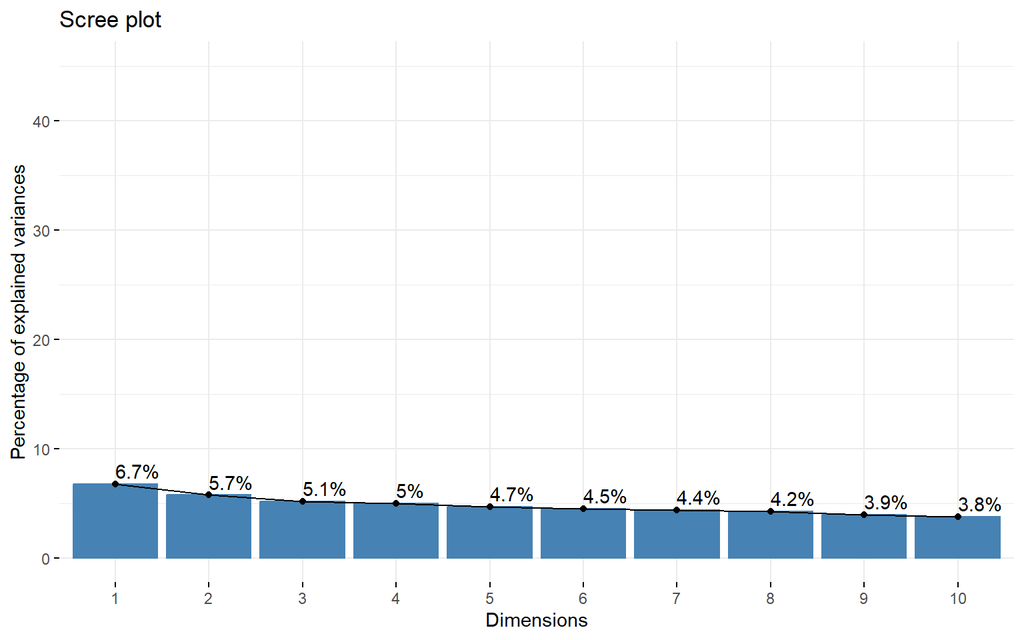

```
## Correlation between variables and principal dimensions for basic_vehicle_df :
```

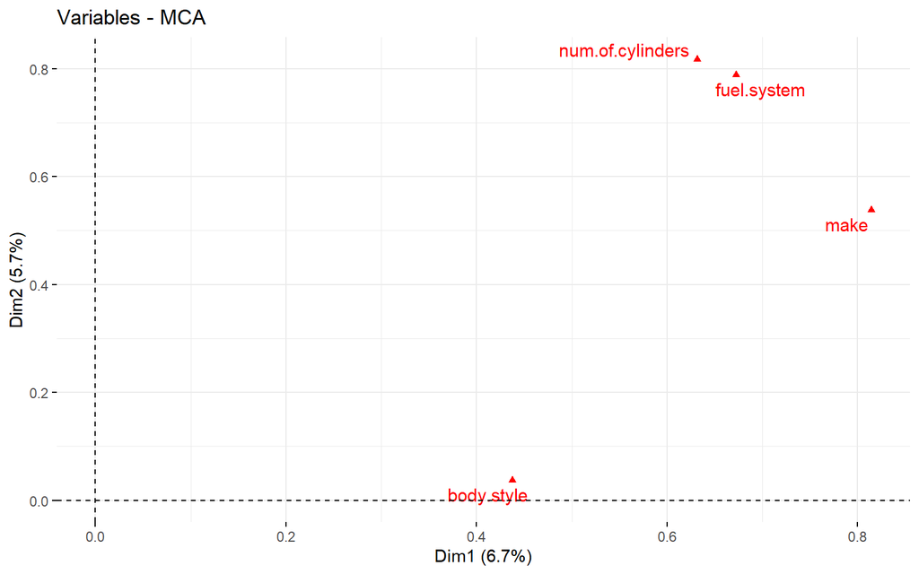

```
## Contribution of variable categories for basic_vehicle_df :
```

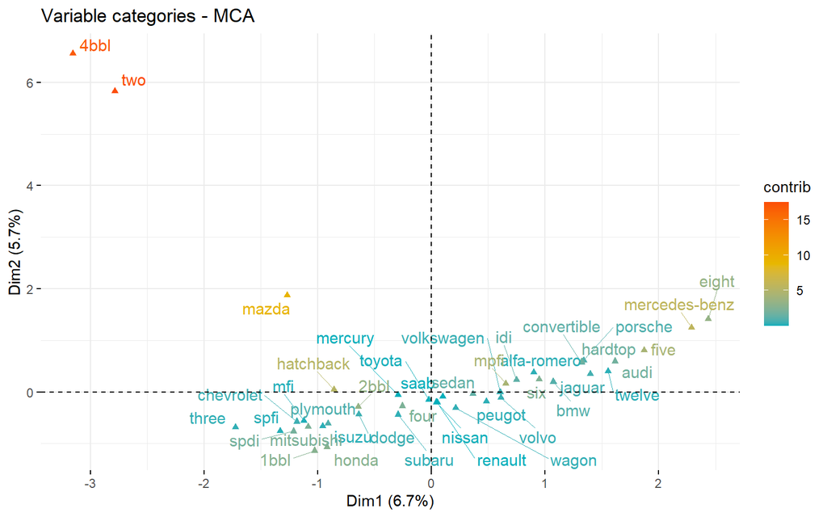

```
## Description of dimensions for basic_vehicle_df :
##
## Link between the variable and the categorical variable (1-way anova)
## =============================================
##                         R2      p.value
## make             0.8141967 2.911828e-54
## fuel.system      0.6720419 2.040006e-43
## num.of.cylinders 0.6311627 1.880503e-39
## body.style       0.4375329 1.418308e-23
##
## Link between variable and the categories of the categorical variables
## ================================================================
##                           Estimate      p.value
## fuel.system=mpfi        1.23251536 2.764148e-21
## make=mercedes-benz      1.72313708 3.033153e-12
## fuel.system=2bbl        0.19323170 6.181866e-11
## num.of.cylinders=five   1.26077561 2.341906e-10
## num.of.cylinders=six    0.52404266 3.738340e-07
## num.of.cylinders=eight  1.71397644 4.384199e-07
## make=audi               1.18415286 4.555396e-05
## body.style=hardtop      0.67929791 1.097290e-04
## fuel.system=idi         1.30570453 3.727545e-04
## body.style=convertible  0.67659693 9.415373e-04
## make=bmw                0.75069994 1.826525e-03
## make=porsche            0.96281952 6.667955e-03
## make=jaguar             1.00920540 1.465181e-02
## make=volkswagen         0.37590910 3.086179e-02
## make=volvo              0.38262755 3.667296e-02
## make=chevrolet         -1.05152764 3.940021e-02
## make=plymouth          -0.83419162 1.417803e-02
## make=honda             -0.84026927 5.625200e-04
## fuel.system=1bbl       -0.11279062 4.054702e-04
## fuel.system=spdi       -0.25982875 1.699973e-04
## make=mitsubishi        -0.97262890 4.190590e-05
## body.style=sedan       -0.08661463 6.617485e-07
## make=mazda             -1.12134796 1.565597e-08
## fuel.system=4bbl       -1.81456745 1.203075e-08
## num.of.cylinders=two   -2.45841048 5.594273e-09
## num.of.cylinders=four  -0.43720123 5.418155e-13
## body.style=hatchback   -1.06232339 4.929354e-22
```

[output cut: 9 more lines]

```
## ================================================================
##                          Estimate      p.value
## num.of.cylinders=two    3.4900357 1.281271e-52
## fuel.system=4bbl        4.5294187 1.104015e-47
## make=mazda              1.3902918 1.077535e-18
## make=mercedes-benz      0.9268035 2.769580e-04
## num.of.cylinders=eight  0.2306546 3.997377e-03
## fuel.system=mpfi       -0.2025608 3.831196e-02
## fuel.system=spdi       -0.8832535 1.915709e-02
## make=mitsubishi        -0.4897449 1.214188e-02
## num.of.cylinders=five  -0.2191883 8.460497e-03
## fuel.system=2bbl       -0.5322184 5.214630e-03
## fuel.system=1bbl       -1.1605673 8.354827e-05
## make=honda             -0.7799784 5.691861e-05
## num.of.cylinders=four  -1.0178188 6.430941e-15
```

## 2.2 MCA Body Style and Location

```r
# # Perform MCA analysis for body_location_df
perform_mca_analysis("body_location_df", mca_results$body_location_df)
```

```
## Summary of MCA results for body_location_df :
##
## Call:
## MCA(X = df, graph = FALSE)
##
##
## Eigenvalues
##                        Dim.1   Dim.2   Dim.3   Dim.4   Dim.5   Dim.6   Dim.7
## Variance               0.539   0.414   0.349   0.333   0.274   0.250   0.174
## % of var.             23.088  17.743  14.945  14.286  11.727  10.732   7.478
## Cumulative % of var.  23.088  40.832  55.777  70.062  81.790  92.522 100.000
##
## Individuals (the 10 first)
##                Dim.1    ctr   cos2    Dim.2    ctr   cos2    Dim.3    ctr
## 1           |  1.413  1.844  0.175 | -0.023  0.001  0.000 | -1.060  1.602
## 2           |  1.413  1.844  0.175 | -0.023  0.001  0.000 | -1.060  1.602
## 3           |  0.134  0.017  0.015 | -0.249  0.075  0.051 |  0.238  0.081
## 4           | -0.307  0.087  0.152 | -0.206  0.051  0.069 | -0.355  0.180
## 5           | -0.309  0.088  0.011 |  1.893  4.308  0.425 | -0.147  0.031
## 6           | -0.307  0.087  0.152 | -0.206  0.051  0.069 | -0.355  0.180
## 7           | -0.307  0.087  0.152 | -0.206  0.051  0.069 | -0.355  0.180
## 8           | -0.328  0.099  0.042 |  0.885  0.942  0.303 |  0.437  0.272
## 9           | -0.307  0.087  0.152 | -0.206  0.051  0.069 | -0.355  0.180
## 10          |  0.239  0.053  0.060 |  0.001  0.000  0.000 | -0.784  0.878
##               cos2
## 1            0.099 |
## 2            0.099 |
## 3            0.046 |
## 4            0.204 |
## 5            0.003 |
## 6            0.204 |
## 7            0.204 |
## 8            0.074 |
## 9            0.204 |
## 10           0.652 |
##
## Categories
##                 Dim.1     ctr    cos2  v.test     Dim.2     ctr    cos2  v.test
## convertible |   2.452  11.101   0.185   6.082 |  -0.139   0.046   0.001  -0.344
## hardtop     |   3.386  28.232   0.475   9.749 |  -0.198   0.126   0.002  -0.570
```

[output cut: 12 more lines]

```
## sedan       |  -0.869  33.745   0.663 -11.517 |
## wagon       |   0.534   3.396   0.041   2.849 |
## front       |  -0.030   0.083   0.058  -3.412 |
## rear        |   1.960   5.482   0.058   3.412 |
## 4wd         |   0.638   1.549   0.017   1.837 |
## fwd         |   0.269   4.059   0.103   4.535 |
## rwd         |  -0.491   8.607   0.144  -5.360 |
##
## Categorical variables (eta2)
##                   Dim.1 Dim.2 Dim.3
## body.style      | 0.693 0.623 0.839 |
## engine.location | 0.585 0.002 0.058 |
## drive.wheels    | 0.338 0.617 0.149 |
## NULL
## Eigenvalues plot for body_location_df :
```

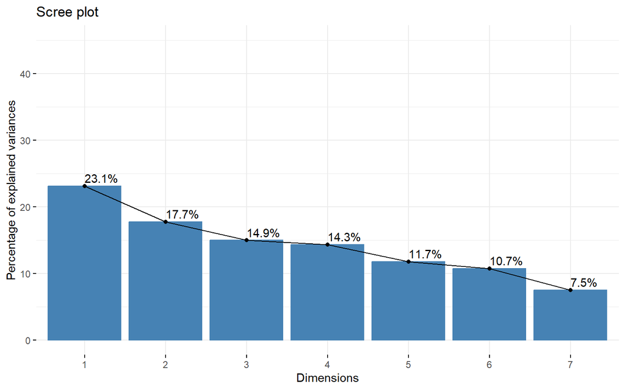

```
## Correlation between variables and principal dimensions for body_location_df :
```

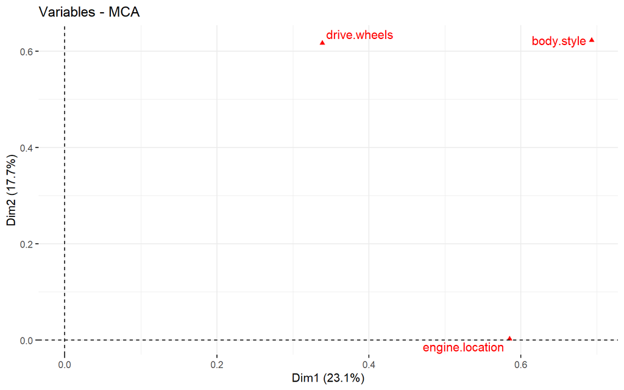

```
## Contribution of variable categories for body_location_df :
```

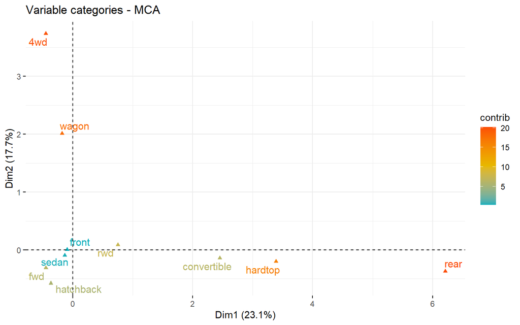

```
## Description of dimensions for body_location_df :
##
## Link between the variable and the categorical variable (1-way anova)
## =============================================
##                        R2      p.value
## body.style      0.6929045 3.899850e-49
## engine.location 0.5848886 7.486685e-40
## drive.wheels    0.3383971 1.734369e-18
##
## Link between variable and the categories of the categorical variables
## ================================================================
##                          Estimate      p.value
## engine.location=rear    2.3147018 7.486685e-40
## body.style=hardtop      1.7276509 1.122770e-29
## drive.wheels=rwd        0.5896129 1.357150e-19
## body.style=convertible  1.0418908 1.875687e-10
## body.style=hatchback   -1.0248289 1.889801e-04
## drive.wheels=fwd       -0.2929892 2.908853e-16
## engine.location=front  -2.3147018 7.486685e-40
##
## Link between the variable and the categorical variable (1-way anova)
## =============================================
##                     R2      p.value
## drive.wheels 0.6169203 5.567078e-42
## body.style   0.6230661 1.848415e-40
##
## Link between variable and the categories of the categorical variables
## ================================================================
##                        Estimate      p.value
## drive.wheels=4wd      1.6525202 2.198677e-39
## body.style=wagon      1.1661256 6.063521e-39
## drive.wheels=fwd     -0.9550052 6.242699e-08
## body.style=hatchback -0.5006467 1.195986e-09
```

The MCA results on the body location group reveal that these variables also explain some of the variance in the dataset. For instance, there’s an association between certain body styles and their location, with hardtops and convertibles being more likely to have a rear engine location. The presence of rear-wheel drive (RWD) is associated with hardtop body styles, suggesting a preference for certain drivetrain configurations in certain body styles. Similarly, the presence of four-wheel drive (4WD) is strongly associated with wagon body styles, indicating a preference for certain drivetrains in utility-oriented body styles.

## 2.3 MCA Engine and Aspiration

```r
# Perform MCA analysis for engine_aspiration_df
perform_mca_analysis("engine_aspiration_df", mca_results$engine_aspiration_df)
```

```
## Summary of MCA results for engine_aspiration_df :
##
## Call:
## MCA(X = df, graph = FALSE)
##
##
## Eigenvalues
##                        Dim.1   Dim.2   Dim.3   Dim.4   Dim.5   Dim.6
## Variance               0.614   0.500   0.500   0.500   0.500   0.386
## % of var.             20.471  16.667  16.667  16.667  16.667  12.863
## Cumulative % of var.  20.471  37.137  53.804  70.471  87.137 100.000
##
## Individuals (the 10 first)
##          Dim.1    ctr   cos2    Dim.2    ctr   cos2    Dim.3    ctr   cos2
## 1     | -0.305  0.075  0.012 |  0.000  0.000  0.000 |  0.000  0.000  0.000 |
## 2     | -0.305  0.075  0.012 |  0.000  0.000  0.000 |  0.000  0.000  0.000 |
## 3     | -0.817  0.541  0.091 | -0.249  0.062  0.008 |  2.435  5.901  0.808 |
## 4     | -0.272  0.060  0.244 | -0.259  0.067  0.223 | -0.199  0.040  0.131 |
## 5     | -0.272  0.060  0.244 | -0.259  0.067  0.223 | -0.199  0.040  0.131 |
## 6     | -0.272  0.060  0.244 | -0.259  0.067  0.223 | -0.199  0.040  0.131 |
## 7     | -0.272  0.060  0.244 | -0.259  0.067  0.223 | -0.199  0.040  0.131 |
## 8     | -0.272  0.060  0.244 | -0.259  0.067  0.223 | -0.199  0.040  0.131 |
## 9     |  1.032  0.863  0.429 | -0.259  0.067  0.027 | -0.199  0.040  0.016 |
## 10    | -0.272  0.060  0.244 | -0.259  0.067  0.223 | -0.199  0.040  0.131 |
##
## Categories
##           Dim.1     ctr    cos2  v.test     Dim.2     ctr    cos2  v.test
## dohc  |  -0.111   0.060   0.001  -0.397 |   0.000   0.000   0.000   0.000 |
## l     |   2.873  40.133   0.524  10.239 |   1.118   7.468   0.079   3.986 |
## ohc   |  -0.060   0.211   0.009  -1.363 |  -0.367   9.709   0.348  -8.348 |
## ohcf  |  -0.410   1.021   0.014  -1.646 |   1.406  14.762   0.160   5.648 |
## ohcv  |  -0.915   4.408   0.058  -3.403 |  -0.352   0.802   0.009  -1.310 |
## rotor |  -1.604   4.167   0.052  -3.232 |   5.814  67.259   0.686  11.715 |
## std   |  -0.366   8.955   0.614 -11.083 |   0.000   0.000   0.000   0.000 |
## turbo |   1.678  41.045   0.614  11.083 |   0.000   0.000   0.000   0.000 |
##         Dim.3     ctr    cos2  v.test
## dohc    0.000   0.000   0.000   0.000 |
## l       1.004   6.017   0.064   3.577 |
## ohc    -0.282   5.732   0.206  -6.415 |
## ohcf   -1.210  10.931   0.118  -4.861 |
## ohcv    3.444  76.714   0.820  12.808 |
## rotor   0.552   0.606   0.006   1.112 |
## std     0.000   0.000   0.000   0.000 |
## turbo   0.000   0.000   0.000   0.000 |
##
## Categorical variables (eta2)
##               Dim.1 Dim.2 Dim.3
## engine.type | 0.614 1.000 1.000 |
## aspiration  | 0.614 0.000 0.000 |
## NULL
## Eigenvalues plot for engine_aspiration_df :
```

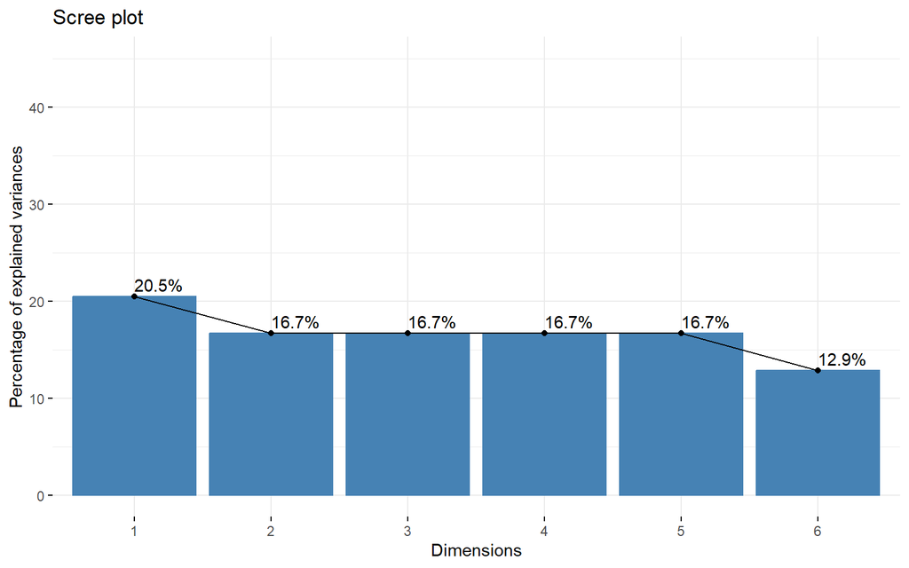

```
## Correlation between variables and principal dimensions for engine_aspiration_df :
```

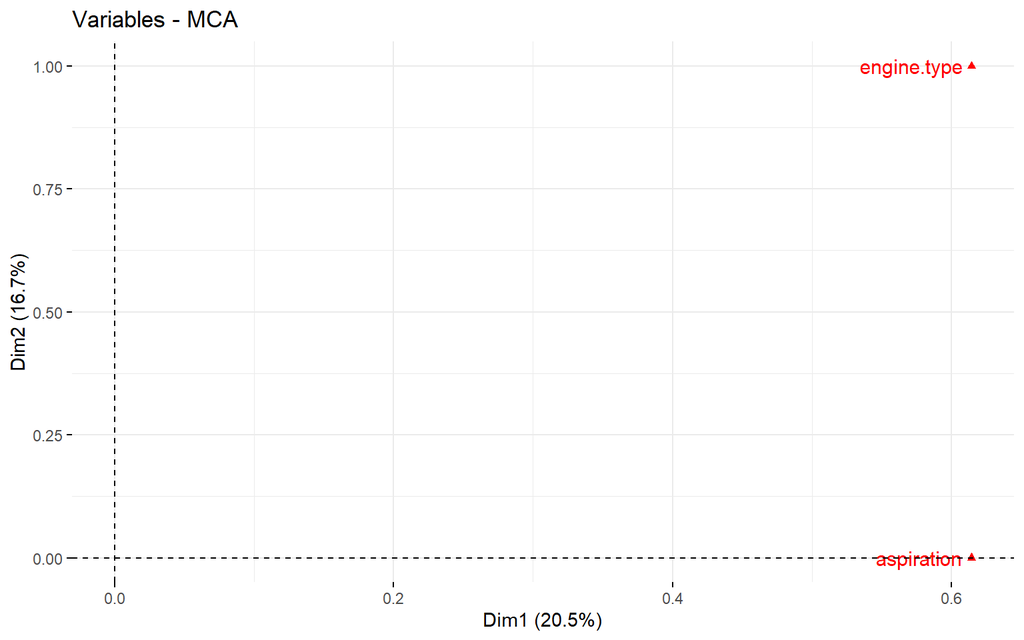

```
## Contribution of variable categories for engine_aspiration_df :
```

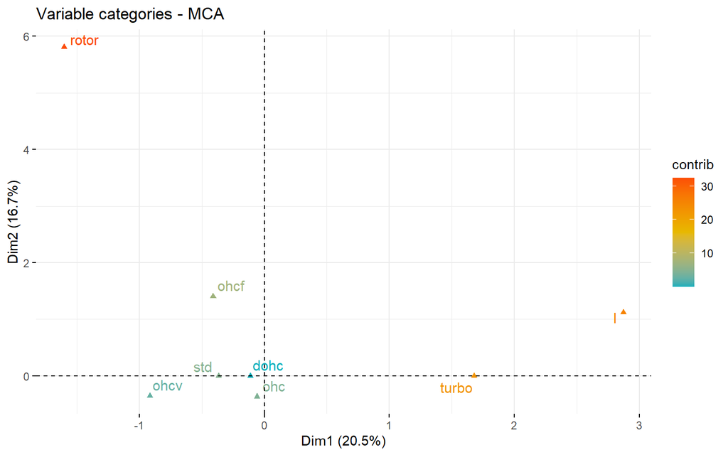

```
## Description of dimensions for engine_aspiration_df :
##
## Link between the variable and the categorical variable (1-way anova)
## =============================================
##                   R2      p.value
## aspiration  0.614121 5.109536e-43
## engine.type 0.614121 1.712700e-38
##
## Link between variable and the categories of the categorical variables
## ================================================================
##                     Estimate      p.value
## aspiration=turbo   0.8008050 5.109536e-43
## engine.type=l      2.2813516 6.194566e-34
## engine.type=rotor -1.2272269 1.102352e-03
## engine.type=ohcv  -0.6874456 5.805852e-04
## aspiration=std    -0.8008050 5.109536e-43
##
## Link between the variable and the categorical variable (1-way anova)
## =============================================
##             R2 p.value
## engine.type  1       0
##
## Link between variable and the categories of the categorical variables
## ================================================================
##                      Estimate      p.value
## engine.type=rotor  3.21286193 5.536402e-52
## engine.type=ohcf   0.09655295 4.266606e-09
## engine.type=l     -0.10710028 5.055736e-05
## engine.type=ohc   -1.15736227 2.906319e-20
```

In conclusion, the application of multiple correspondence analysis (MCA) sheds light on intricate patterns within the dataset. Through MCA, we discern how various variables collectively contribute to explaining the variance, offering insights into the underlying structure of the data. The analysis unveils associations between luxury car manufacturers and specific body styles, as well as the influence of engine characteristics, such as cylinder numbers and fuel systems, on car make clustering. Moreover, the examination of body location and engine aspiration characteristics reveals further nuances in how certain features align with one another, emphasizing the interconnectedness of automotive attributes.